# CITS4009 - Project 1

## Earnings by category

Next we analyze how earnings differ across different YouTube channel categories.

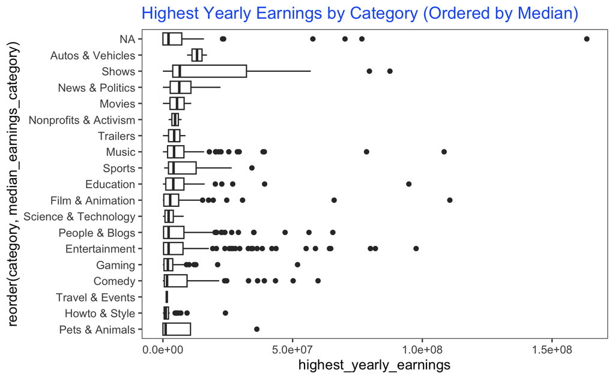

```r
# Calculate median for each category
df$median_earnings_category <- with(df, ave(highest_yearly_earnings, category, FUN=median))

# Create the boxplot
ggplot(df, aes(x = reorder(category, median_earnings_category), y = highest_yearly_earnings)) +
  geom_boxplot() +
  coord_flip() +
  ggtitle("Highest Yearly Earnings by Category (Ordered by Median)") +
  color_theme
```

All categories have similar median values except Autos & Vehicles, whose median is significantly larger than others. Pets & Animals channel has the smallest median value of highest yearly earnings.

## Earnings by country

We can analyse the highest yearly earnings of the top 995 YouTube channels by country. There are too many countries in the dataset so we select 20 countries with the largest median value of highest yearly earnings.

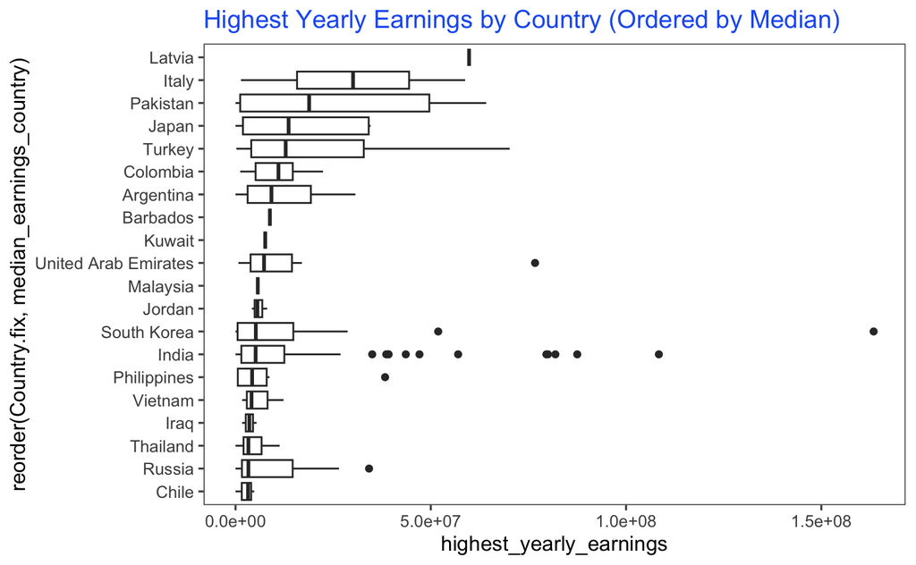

```r
# Calculate median for each country
df$median_earnings_country <- with(df, ave(highest_yearly_earnings, Country.fix, FUN=median))

# Sort the data frame
df_median_earnings_country_des <- df %>%
                                  arrange(desc(median_earnings_country))
# Get unique country names
unique_countries <- unique(df_median_earnings_country_des$Country)

# Select the first 20 unique country names
selected_countries <- unique_countries[1:20]

# Get all rows of the top 20 countries
top_20_country <- df_median_earnings_country_des[df_median_earnings_country_des$Country %in% selected_countries, ]

# Create the boxplot
ggplot(top_20_country, aes(x = highest_yearly_earnings, y = reorder(Country.fix, median_earnings_country))) +
  geom_boxplot() +
  ggtitle("Highest Yearly Earnings by Country (Ordered by Median)") +
  color_theme
```

```r
top_20_country
```

[output not shown]

The popular channel from Latvia has a distinctively higher value of highest yearly earnings among all the countries.

# EDA: Geospatial information

With longitude and latitude provided in the dataset, we are able to visualise the country distribution in the aspect of earnings analysis.

```r
# Data preparation
visit.x<-df$Longitude
visit.y<-df$Latitude

mp<-NULL #Create an empty map
mapworld<-borders("world",colour = "gray50",fill="white") #Draw the map
mp<-ggplot()+mapworld+ylim(-60,90)
mp2<-mp+geom_point(aes(x=visit.x,y=visit.y,size=df$highest_yearly_earnings),color=my_color)+
  scale_size(range=c(2,9))+
  ggtitle("Geospatial Information About Highest Yearly Earnings")+
  theme(plot.title=element_text(size=25,color="red",face="italic"))+
  theme_grey(base_size = 32)
mp3<-mp2+color_theme+theme(legend.position = "none")
mp3
```

[output not shown]

# EDA: Trend by time